# Graficas

CN

2023-10-22

## Los gráficos en R

R dispone de múltiples funciones diseñadas para la representación gráfica de datos. Estas funciones se dividen en dos grandes grupos: funciones gráficas de alto nivel y de bajo nivel. La diferencia fundamental es que las funciones de alto nivel son las que generan gráficos completos, mientras que las de bajo nivel se limitan a añadir elementos a un gráfico existente (por tanto creado por una función de alto nivel).

El paquete graphics (que se carga en memoria cada vez que arrancamos R) contiene un buen número de funciones de alto y bajo nivel para generar gráficos. Numerosos paquetes -plotrix, scatterplot3D, rgl, maps, shapes, …, y sobre todo ggplot2- contienen muchísimas más funciones gráficas que mejoran y complementan las que vienen por defecto con R.

## Funciones gráficas de alto nivel

Estas funciones son las que generan gráficos completos. Entre las más utilizadas podemos citar plot() (gráficos de nubes de puntos, entre otros), hist() (histogramas), barplot() (diagramas de barras), boxplot() (diagramas de caja y bigote), pie() (diagrama de sectores) o pers() (superficies en 3D). Todas estas funciones disponen de multitud de argumentos que permiten controlar las etiquetas de los ejes, sus límites, títulos, tamaño, colores, etc.:

- xlim, ylim: controlan, respectivamente, la extensión de los ejes X e Y. Así xlim=c(0,10) indica que el eje X se extiende de 0 a 10; ylim=c(-5,5) indica que el eje Y va de -5 a 5. Si no se incluyen estos valores, R los ajusta por defecto de modo que se incluyan todos los valores disponibles en el dataframe.
- xlab e ylab especifican las etiquetas para los ejes X e Y respectivamente.
- main indica el título del gráfico.
- sub permite especificar un subtítulo.

Los ejemplos que se muestran más abajo permiten ver como utilizar estas opciones.

Dos argumentos importantes que son comunes a la mayoría de gráficos de alto nivel son los siguientes:

- add=TRUE: fuerza a la función a actuar como si fuese de bajo nivel (intenta superponer la figura que genera a un gráfico ya existente). Esta opción no está disponible para todas las funciones.
- type Indica el tipo de gráfico a realizar. En concreto:
  - type=“p” representa puntos (opción por defecto)
  - type=“l” representa líneas
  - type=“b” (both, ambos) representa puntos unidos por líneas.
  - type=“n” No dibuja nada.

## Funciones gráficas de bajo nivel:

Permiten añadir líneas, puntos, etiquetas… a un gráfico ya existente. Son de gran utilidad para completar un gráfico. Entre estas funciones cabe destacar:

- lines(): Permite añadir lineas (uniendo puntos concretos) a una gráfica ya existente.
- abline(): Añade lineas horizontales, verticales u oblicuas, indicando pendiente y ordenada.
- points(): Permite añadir puntos.
- legend(): Permite añadir una leyenda.
- text(): Añade texto en las posiciones que se indiquen.
- grid(): Añade una malla de fondo.
- title(): permite añadir un título o subtítulo.

## Argumentos comunes a las funciones gráficas de alto y bajo nivel

Los siguientes argumentos opcionales son comunes a muchas funciones gráficas de alto y bajo nivel. Sus valores por defecto pueden obtenerse ejecutando la función par(). Se puede encontrar el significado y valores posibles de cada uno de estos argumentos (y muchos más) ejecutando help(par).

## Ejemplos de funciones gráficas de alto nivel

Podemos destacar, entre las más utilizadas:

### plot()

Esta función ofrece muchas variantes dependiendo del tipo de objeto al que se aplique. El caso más simple corresponde a la representación de dos variables x e y. En tal caso, plot(x,y) representa un diagrama de dispersión de puntos de y frente a x.

A modo de ejemplo se muestra a continuación un gráfico de la esperanza de vida (LifeExpectancy, que será nuestra variable y) frente al índice de felicidad (Happiness, que es la x) en una muestra de 143 países. Los datos se encuentran en el dataframe(HappyPlanetIndex) del paquete (Lock5Data) (consultar help(HappyPlanetIndex) para ver las variables en este dataframe, y http://www.happyplanetindex.org/about/ para más información sobre este estudio):

### Nota

Se debe instalar el paquete lock5data

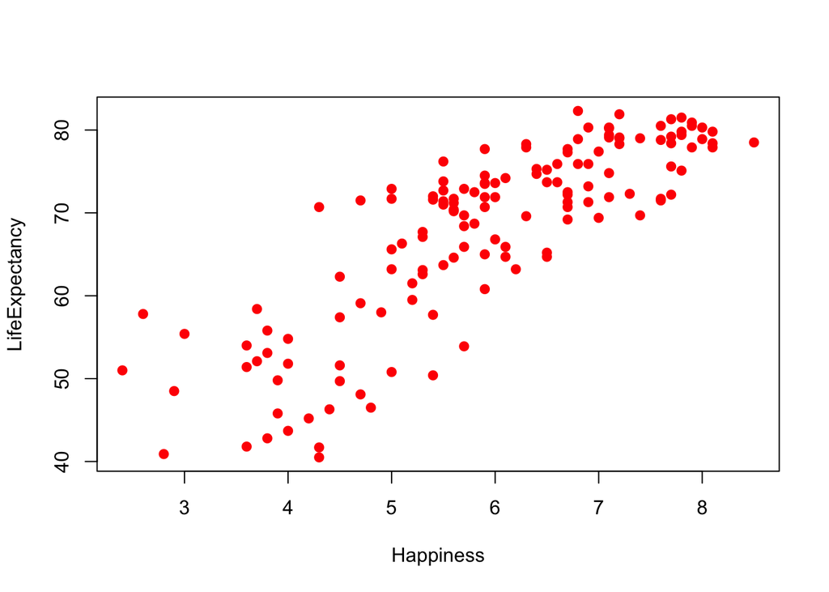

```r
library(Lock5Data)
data(HappyPlanetIndex)
attach(HappyPlanetIndex)
plot(Happiness,LifeExpectancy,pch=19,col="red")
```

### hist()

Esta función permite dibujar histogramas de frecuencias para variables continuas. Por ejemplo, el histograma de los niveles de felicidad en los distintos países de la muestra se obtiene fácilmente como:

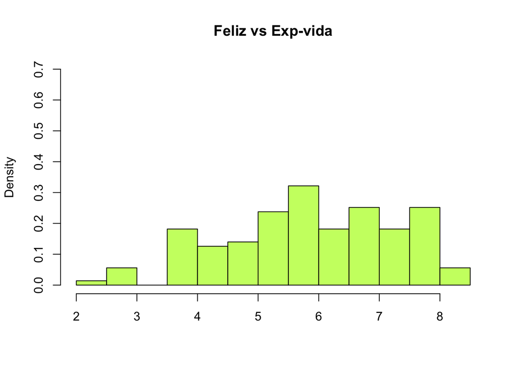

```r
hist(HappyPlanetIndex$Happiness,col="darkolivegreen1",ylim=c(0,0.7),main="Feliz vs Exp-vida",xlab="",freq = FALSE)
```

Función de densidad.

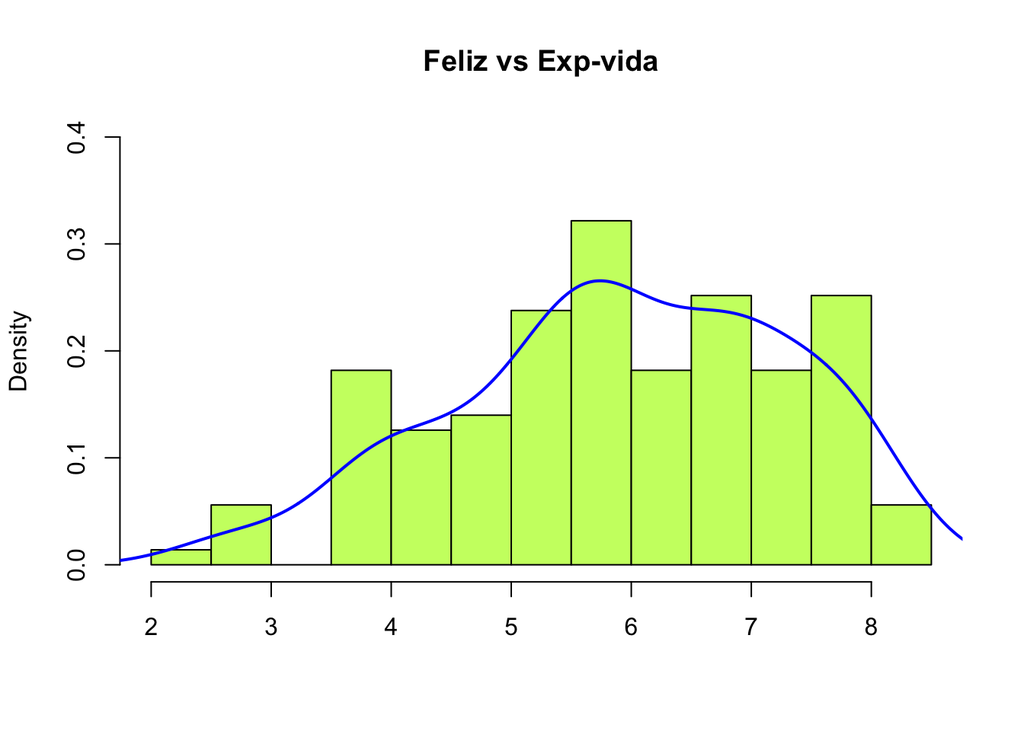

```r
hist(HappyPlanetIndex$Happiness,col="darkolivegreen1",ylim=c(0,0.4),main="Feliz vs Exp-vida",xlab="",freq = FALSE)
lines(density(HappyPlanetIndex$Happiness),col="blue",lwd=2)
```

En el mismo paquete Lock5Data se puede encontrar el dataframe SalaryGender que contiene una muestra de 100 profesores universitarios de EEUU, 50 hombres y 50 mujeres; para cada uno se tiene el salario anual (en miles de dólares), la edad y la variable PhD que vale 1 si el profesor es doctor y 0 si no lo es. Podemos ver la distribución de salarios entre hombres y mujeres mediante un histograma combinado utilizando la función histStack() del paquete plotrix:

### Nota

se debe instalar el paquete plotrix

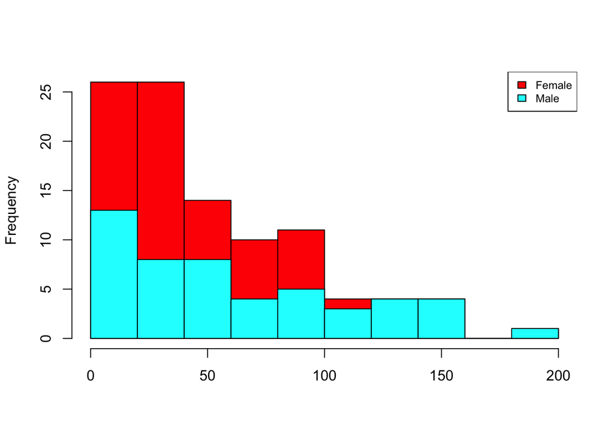

```r
data(SalaryGender)
attach(SalaryGender)
Gender=factor(Gender,levels=c(0,1),labels=c("Female","Male"))
library(plotrix)
histStack(Salary,Gender,legend.pos="topright")
```

### barplot()

Se utiliza para dibujar diagramas de barras. El siguiente ejemplo muestra el número de países en cada una de las 7 regiones en que se dividió el planeta para el estudio de los niveles de felicidad:

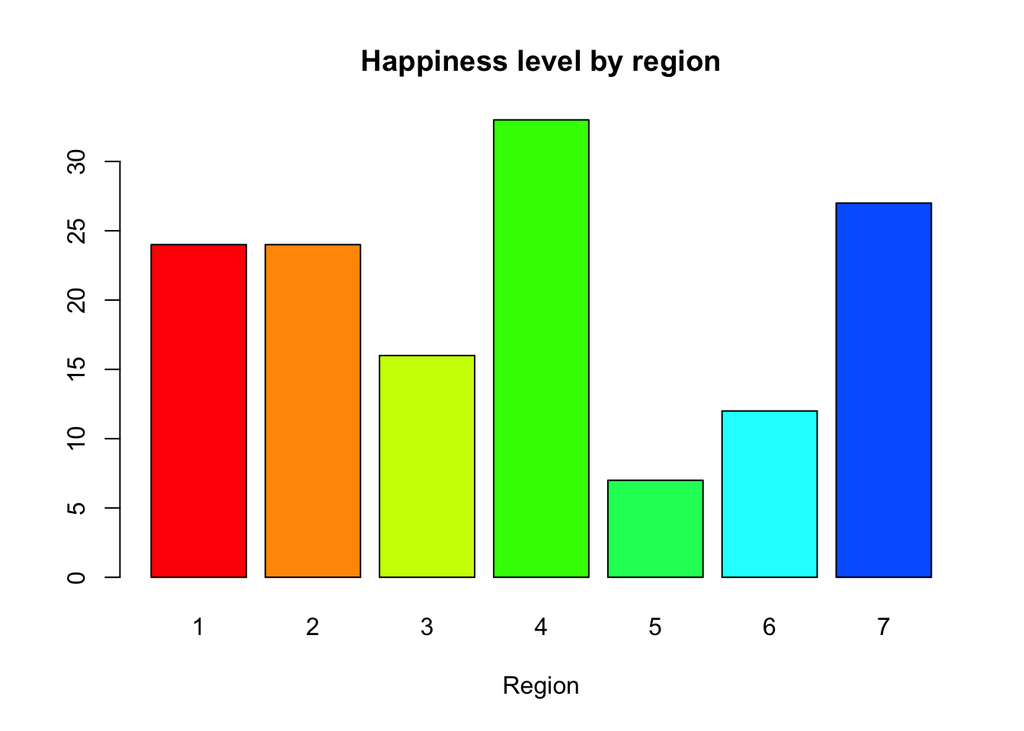

```r
barplot(table(Region),xlab="Region",main="Happiness level by region", col=rainbow(10))
```

El paquete plotrix contiene la función barp() que permite dar “volumen” a la barras:

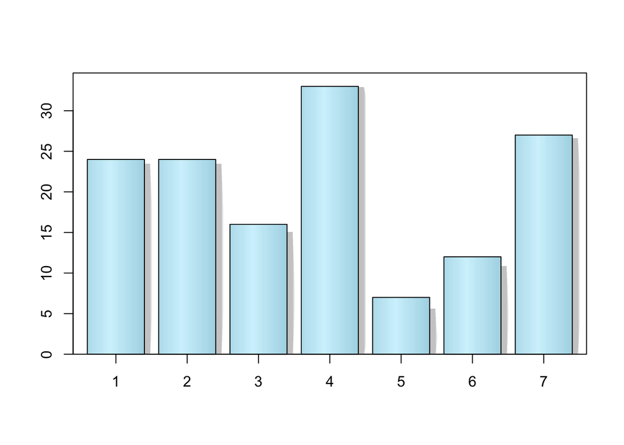

```r
barp(table(Region),col="lightblue",cylindrical=TRUE,shadow=TRUE)
```

Es posible construir diagramas de barras por categorías; podemos, por ejemplo representar la frecuencia de doctores por sexo utilizando los datos del dataframe SalaryGender:

[figure not shown]

```r
PhD=factor(PhD,levels=c(0,1),c("PhD","non PhD"))
barplot(table(Gender,PhD),beside=TRUE,legend.text=TRUE,col=c("pink","cyan"))
```

### pie()

Aporta la misma información que el diagrama de barras, pero en forma de diagrama de sectores:

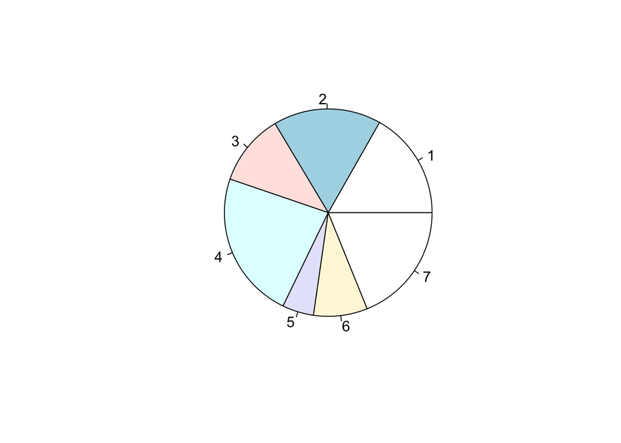

```r
pie(table(Region))
```

El paquete plotrix permite elaborar diagramas de sectores en 3D mediante la función pie3D:

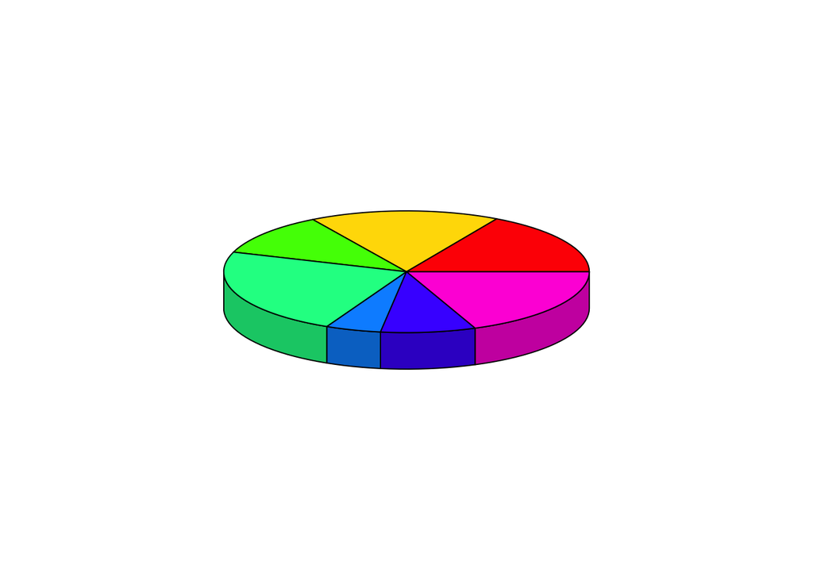

```r
pie3D(table(Region))
```

### boxplot()

Lleva a cabo la representación de gráficos de “caja y bigote”. El siguiente ejemplo muestra el reparto de los niveles de felicidad entre las distintas regiones del globo:

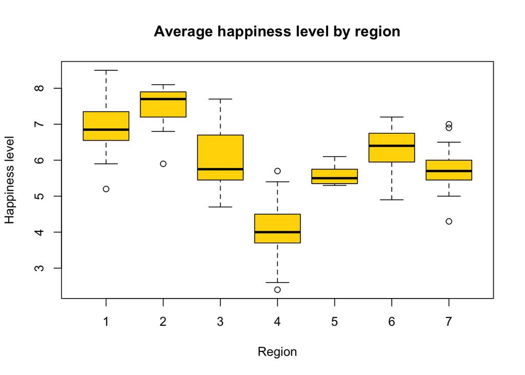

```r
boxplot(Happiness~Region,col="gold",xlab="Region",ylab="Happiness level",
        main="Average happiness level by region")
```